# Weight Lifting Project

Hao Hong

Sunday, May 24, 2015

# Introduction

This is a course project for “Practical Machine Learning” on COURSERA. The goal of this project is to predict the manner in which people do the weight-lifting exercise. I tried the decision tree model and the random forest model and found the latter outperform the former. With the random forest model, I correctly predicted 19 of the 20 behavior manners in the testing set.

# Data

I used the weight lifting data developed by Velloso et al. (2013) in this project. In their data collection, subjects were asked to perform barbell lifts correctly and incorrectly in 5 different ways. Data were collected from accelerometers on the belt, forearm, arm, and dumbbell of 6 participants. More information about the data is available from the website here: http://groupware.les.inf.puc-rio.br/har (see the section on the Weight Lifting Exercise Dataset).

I downloaded the data for this project from the Coursera website.

The data has been already sliced into the training data (19622 observations) and the testing data (20 observations).

The variable denoting the weight lifting manner is the “classe” variable in the training and testing data set. It takes five values between letters “A” to “E”. The values of the “classe” are defined as follows: exactly according to the specification (Class A), throwing the elbows to the front (Class B), lifting the dumbbell only halfway (Class C), lowering the dumbbell only halfway (Class D) and throwing the hips to the front (Class E).

# Data Cleaning

The data set includes two types of data: real-time 45Hz readings from sensors, and sliding window data calculated on 2.5-second windows. The test data only contains features collected by real-time readings. So I only select the real-time data to train my model (observations with valued “no” in the “new_window” variable). Correspondingly, I dropped features calculated in the sliding windows (variabes with prefix of average, variance, standard deviation, max, min, amplitude, kurtosis and skewness). I also dropped information that are not obtained by the movement sensors: “user_name”, “raw_timestamp_part_1”, “raw_timestamp_part_2”, “cvtd_timestamp”, “new_window”, “num_window”, which are the first 7 variables in the raw training data.

The selected training data includes 19216 observations and 52 features. The names of these features are as follows:

```
##  [1] "accel_arm_x"          "accel_arm_y"          "accel_arm_z"
##  [4] "accel_belt_x"         "accel_belt_y"         "accel_belt_z"
##  [7] "accel_dumbbell_x"     "accel_dumbbell_y"     "accel_dumbbell_z"
## [10] "accel_forearm_x"      "accel_forearm_y"      "accel_forearm_z"
## [13] "gyros_arm_x"          "gyros_arm_y"          "gyros_arm_z"
## [16] "gyros_belt_x"         "gyros_belt_y"         "gyros_belt_z"
## [19] "gyros_dumbbell_x"     "gyros_dumbbell_y"     "gyros_dumbbell_z"
## [22] "gyros_forearm_x"      "gyros_forearm_y"      "gyros_forearm_z"
## [25] "magnet_arm_x"         "magnet_arm_y"         "magnet_arm_z"
## [28] "magnet_belt_x"        "magnet_belt_y"        "magnet_belt_z"
## [31] "magnet_dumbbell_x"    "magnet_dumbbell_y"    "magnet_dumbbell_z"
## [34] "magnet_forearm_x"     "magnet_forearm_y"     "magnet_forearm_z"
## [37] "pitch_arm"            "pitch_belt"           "pitch_dumbbell"
## [40] "pitch_forearm"        "roll_arm"             "roll_belt"
## [43] "roll_dumbbell"        "roll_forearm"         "total_accel_arm"
## [46] "total_accel_belt"     "total_accel_dumbbell" "total_accel_forearm"
## [49] "yaw_arm"              "yaw_belt"             "yaw_dumbbell"
## [52] "yaw_forearm"
```

# Model Training

```
##
## Call:
## preProcess.default(x = tmp, method = "pca")
##
## Created from 19216 samples and 52 variables
## Pre-processing: principal component signal extraction, scaled, centered
##
## PCA needed 25 components to capture 95 percent of the variance
```

I first use a tree model. Apparently, the model predict too many class A behavior and too few class D behavior. I get an accuracy of 0.400.

```r
ctrl <- trainControl(allowParallel=TRUE)
model1 <- train(training$classe ~ . , method = "rpart", trControl = ctrl, data = trainingPCA)
model1$finalModel
```

```
## n= 19216
##
## node), split, n, loss, yval, (yprob)
##       * denotes terminal node
##
## 1) root 19216 13745 A (0.28 0.19 0.17 0.16 0.18)
##   2) PC14>=-0.8903053 17244 11838 A (0.31 0.19 0.19 0.17 0.14)
##     4) PC8< 1.303306 14147  9143 A (0.35 0.17 0.22 0.11 0.14) *
##     5) PC8>=1.303306 3097  1827 D (0.13 0.24 0.058 0.41 0.16) *
##   3) PC14< -0.8903053 1972   894 E (0.033 0.26 0.03 0.13 0.55) *
```

```r
print(model1)
```

```
## CART
##
## 19216 samples
##    24 predictor
##     5 classes: 'A', 'B', 'C', 'D', 'E'
##
## No pre-processing
## Resampling: Bootstrapped (25 reps)
##
## Summary of sample sizes: 19216, 19216, 19216, 19216, 19216, 19216, ...
##
## Resampling results across tuning parameters:
##
##   cp          Accuracy   Kappa       Accuracy SD  Kappa SD
##   0.03768643  0.3994845  0.20370371  0.02062082   0.04056147
##   0.06315024  0.3637321  0.13949311  0.02120112   0.03969279
##   0.07369953  0.3052361  0.03675355  0.02666988   0.04235578
##
## Accuracy was used to select the optimal model using  the largest value.
## The final value used for the model was cp = 0.03768643.
```

```r
model2 <- train(training$classe ~ . , method = "rf", trControl = ctrl, data = trainingPCA)
model2$finalModel
```

```
##
## Call:
##  randomForest(x = x, y = y, mtry = param$mtry)
##                Type of random forest: classification
##                      Number of trees: 500
## No. of variables tried at each split: 2
##
##         OOB estimate of  error rate: 1.7%
## Confusion matrix:
##      A    B    C    D    E class.error
## A 5441    8   14    5    3 0.005483458
## B   54 3638   23    0    3 0.021516945
## C    5   33 3289   21    4 0.018794749
## D    5    1  104 3033    4 0.036224976
## E    0    8   19   12 3489 0.011054422
```

```r
print(model2)
```

```
## Random Forest
##
## 19216 samples
##    24 predictor
##     5 classes: 'A', 'B', 'C', 'D', 'E'
##
## No pre-processing
## Resampling: Bootstrapped (25 reps)
##
## Summary of sample sizes: 19216, 19216, 19216, 19216, 19216, 19216, ...
##
## Resampling results across tuning parameters:
##
##   mtry  Accuracy   Kappa      Accuracy SD  Kappa SD
##    2    0.9741765  0.9673207  0.002270462  0.002869652
##   13    0.9685670  0.9602259  0.002085332  0.002645220
##   25    0.9581753  0.9470792  0.003916191  0.004971587
##
## Accuracy was used to select the optimal model using  the largest value.
## The final value used for the model was mtry = 2.
```

Although I have used the PCA method to reduce features, the model above still takes a hour to train. Therefore I look at the importance of variables for this random forest model.

```r
library(caret)
imp <- varImp(model2)
print(imp)
```

```
## rf variable importance
##
##   only 20 most important variables shown (out of 25)
##
##      Overall
## PC8   100.00
## PC14   91.88
## PC12   85.44
## PC1    82.85
## PC5    74.83
## PC3    69.37
## PC9    61.39
## PC15   59.29
## PC6    57.08
## PC2    55.85
## PC16   48.83
## PC21   48.25
## PC17   45.65
## PC7    44.18
## PC10   42.07
## PC22   41.84
## PC13   40.05
## PC4    38.60
## PC25   35.17
## PC20   31.45
```

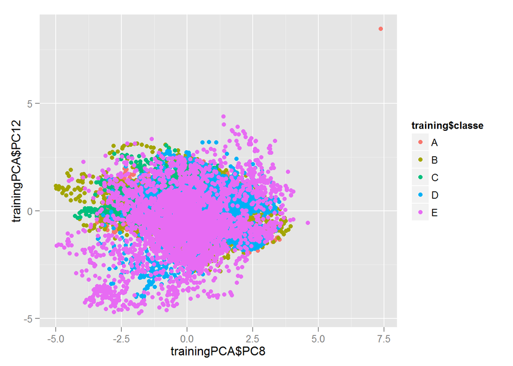

For the third model, I continue to use the random forest model but only use only the 10 most important PCA vectors in model 2.

```r
imp <- varImp(model2)
selectPCA <- trainingPCA[,order(imp$importance,decreasing = TRUE)[1:10] ]
model3 <- train(training$classe ~ . , method = "rf", trControl = ctrl, data = selectPCA)
model3$finalModel
```

```
##
## Call:
##  randomForest(x = x, y = y, mtry = param$mtry)
##                Type of random forest: classification
##                      Number of trees: 500
## No. of variables tried at each split: 2
##
##         OOB estimate of  error rate: 4.02%
## Confusion matrix:
##      A    B    C    D    E class.error
## A 5332   29   62   39    9  0.02540669
## B   94 3507   95    9   13  0.05675094
## C   16   67 3199   55   15  0.04564439
## D   26    8  143 2963    7  0.05846838
## E   12   22   36   16 3442  0.02437642
```

```r
print(model3)
```

```
## Random Forest
##
## 19216 samples
##     9 predictor
##     5 classes: 'A', 'B', 'C', 'D', 'E'
##
## No pre-processing
## Resampling: Bootstrapped (25 reps)
##
## Summary of sample sizes: 19216, 19216, 19216, 19216, 19216, 19216, ...
##
## Resampling results across tuning parameters:
##
##   mtry  Accuracy   Kappa      Accuracy SD  Kappa SD
##    2    0.9437164  0.9287770  0.002971995  0.003747990
##    6    0.9364995  0.9196468  0.003487661  0.004394424
##   10    0.9258016  0.9061124  0.004176053  0.005234051
##
## Accuracy was used to select the optimal model using  the largest value.
## The final value used for the model was mtry = 2.
```

# Prediction

Now I pesent the prediction results on the test set using each of the three models:

```r
# Predictions on test set by the decision tree method
print(prediction1)
```

```
##  [1] A A A A A A D A A A A A A A A A A A A E
## Levels: A B C D E
```

```r
# Predictions on test set by the random forest model
print(prediction2)
```

```
##  [1] B A A A A E D B A A B C B A E E A B B B
## Levels: A B C D E
```

```r
# Predictions on test set by the random forest model, using only 10 PCA vectors
print(prediction3)
```

```
##  [1] A A A A A E D B A A A C B A E E A B B B
## Levels: A B C D E
```

# Conclusion

In this project, I have tried two methods and three models to predict manners of exercise. The random forest model performs better than the decision tree model both in the accuracy of held-out samples in the training set and in prediction accuracy of the test set.

# Reference

Velloso, E.; Bulling, A.; Gellersen, H.; Ugulino, W.; Fuks, H. Qualitative Activity Recognition of Weight Lifting Exercises. Proceedings of 4th International Conference in Cooperation with SIGCHI (Augmented Human ’13) . Stuttgart, Germany: ACM SIGCHI, 2013.